# Chapter 18: Multiple Linear Regression Model

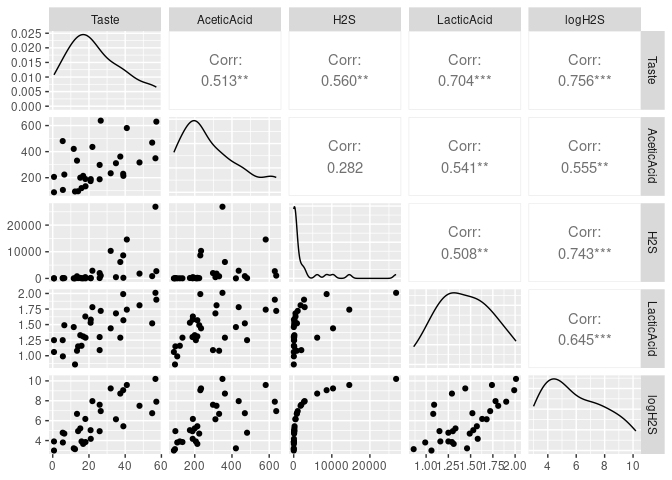

```r
 GGally::ggpairs(data=cheese)
## Registered S3 method overwritten by 'GGally':
##   method from
##   +.gg   ggplot2
```

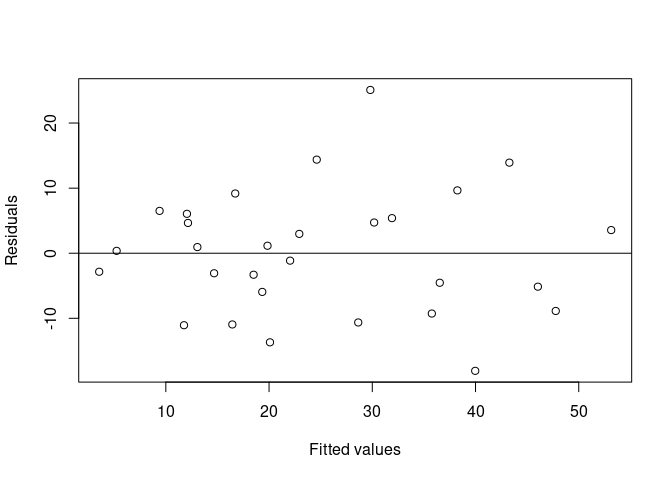

```r
 cheese.lm <- lm(Taste ~ AceticAcid +  LacticAcid + logH2S, data=cheese, subset=2:30)
 # Check the diagnostics
 plot(cheese.lm$fit, cheese.lm$res, xlab="Fitted values", ylab = "Residuals")
 abline(h=0)
```

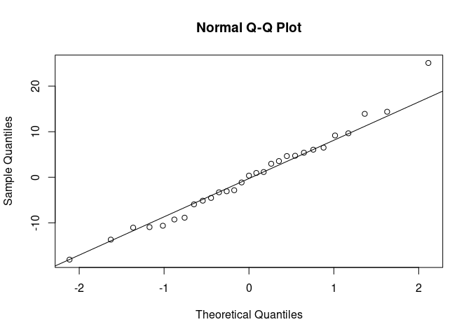

```r
 # Should be a random scatter
 qqnorm(cheese.lm$res)
 qqline(cheese.lm$res)
```

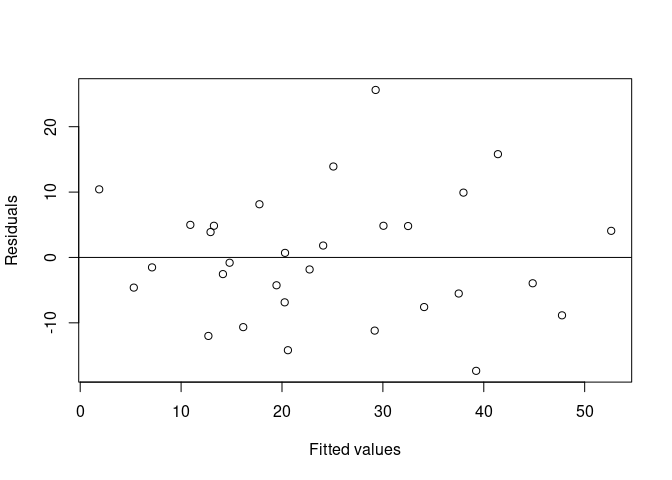

```r
 summary(cheese.lm)
##
## Call:
## lm(formula = Taste ~ AceticAcid + LacticAcid + logH2S, data = cheese,
##     subset = 2:30)
##
## Residuals:
##      Min       1Q   Median       3Q      Max
## -18.0718  -5.9432   0.3657   5.3919  25.0876
##
## Coefficients:
##              Estimate Std. Error t value Pr(>|t|)
## (Intercept) -31.41789    9.95702  -3.155  0.00414 **
## AceticAcid    0.00478    0.01484   0.322  0.74997
## LacticAcid   21.70560    8.69079   2.498  0.01945 *
## logH2S        3.84994    1.21284   3.174  0.00396 **
## ---
## Signif. codes:  0 '***' 0.001 '**' 0.01 '*' 0.05 '.' 0.1 ' ' 1
##
## Residual standard error: 10.06 on 25 degrees of freedom
## Multiple R-squared:  0.6631, Adjusted R-squared:  0.6227
## F-statistic:  16.4 on 3 and 25 DF,  p-value: 4.222e-06
 cheese.lm2 <- lm(Taste ~ LacticAcid + logH2S, data=cheese)
 # Check the diagnostics
 plot(cheese.lm2$fit, cheese.lm2$res, xlab="Fitted values", ylab = "Residuals")
 abline(h=0)
```

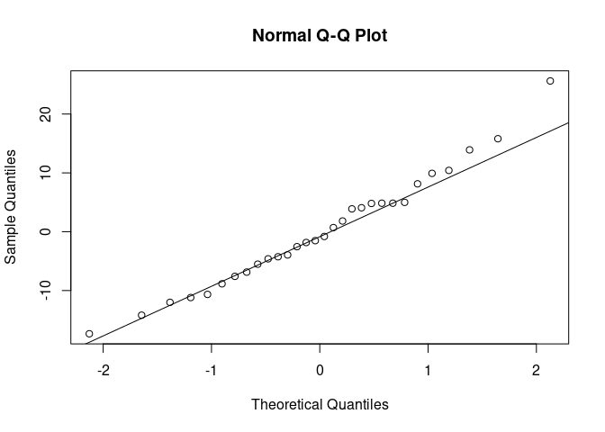

```r
 qqnorm(cheese.lm2$res)
 qqline(cheese.lm2$res)
```

```r
 summary(cheese.lm2)
##
## Call:
## lm(formula = Taste ~ LacticAcid + logH2S, data = cheese)
##
## Residuals:
##     Min      1Q  Median      3Q     Max
## -17.343  -6.529  -1.164   4.844  25.618
##
## Coefficients:
##             Estimate Std. Error t value Pr(>|t|)
## (Intercept)  -27.592      8.982  -3.072  0.00481 **
## LacticAcid    19.888      7.959   2.499  0.01885 *
## logH2S         3.946      1.136   3.475  0.00174 **
## ---
## Signif. codes:  0 '***' 0.001 '**' 0.01 '*' 0.05 '.' 0.1 ' ' 1
##
## Residual standard error: 9.942 on 27 degrees of freedom
## Multiple R-squared:  0.6517, Adjusted R-squared:  0.6259
## F-statistic: 25.26 on 2 and 27 DF,  p-value: 6.552e-07
 # How can we predict?
 newcheese <- data.frame(AceticAcid = 300, LacticAcid = 1.5, logH2S=4)
 cheese.pred <- predict(cheese.lm2, newdata=newcheese, se.fit=TRUE)
 cheese.pred
## $fit
##        1
## 18.02409
##
## $se.fit
## [1] 3.111924
##
## $df
## [1] 27
##
## $residual.scale
## [1] 9.942372
 # Obtain confidence interval
 cheese.pred$fit + c(-1, 1) * qt(0.975, df=27) * cheese.pred$se.fit
## [1] 11.63895 24.40923
 # Using R to predict
 cheese.pred.conf.limits <- predict(cheese.lm2, newdata=newcheese, interval="confidence")
 cheese.pred.conf.limits
##        fit      lwr      upr
## 1 18.02409 11.63895 24.40923
 # How to find prediction interval
 cheese.pred.pred.limits <- predict(cheese.lm2, newdata=newcheese, interval="prediction")
 cheese.pred.pred.limits
##        fit       lwr      upr
## 1 18.02409 -3.351891 39.40007
```

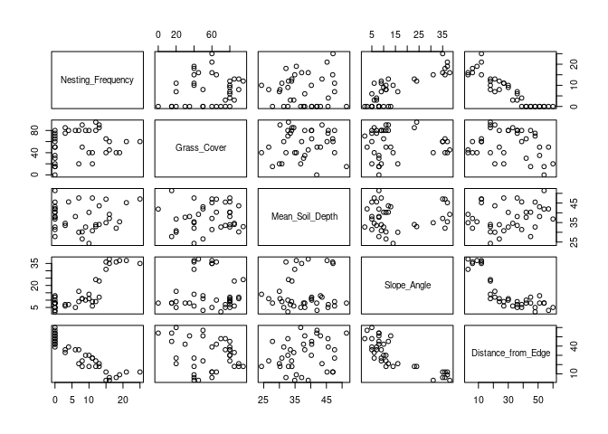

```r
pairs(puffin)
```

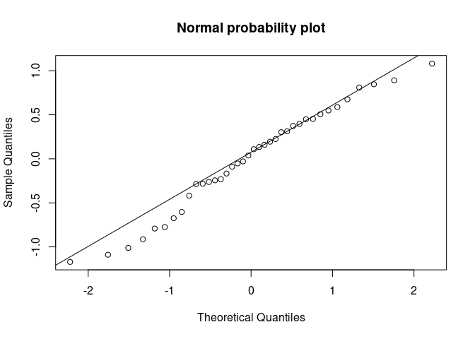

```r
summary(puffin)
##  Nesting_Frequency  Grass_Cover    Mean_Soil_Depth  Slope_Angle
##  Min.   : 0.000    Min.   : 0.00   Min.   :24.30   Min.   : 2.00
##  1st Qu.: 0.000    1st Qu.:40.00   1st Qu.:32.75   1st Qu.: 7.25
##  Median : 7.500    Median :60.00   Median :37.40   Median :10.00
##  Mean   : 7.684    Mean   :56.45   Mean   :37.72   Mean   :15.00
##  3rd Qu.:12.750    3rd Qu.:80.00   3rd Qu.:42.83   3rd Qu.:21.25
##  Max.   :25.000    Max.   :95.00   Max.   :51.40   Max.   :38.00
##  Distance_from_Edge
##  Min.   : 3.00
##  1st Qu.:18.00
##  Median :30.00
##  Mean   :30.39
##  3rd Qu.:44.25
##  Max.   :60.00
puffin$sqrtfreq <- sqrt(puffin$Nesting_Frequency)


puff.sqlm <- lm(sqrtfreq~ Grass_Cover + Mean_Soil_Depth + Slope_Angle
      + Distance_from_Edge, data=puffin)


#par(mfrow=c(2,1))
qqnorm(puff.sqlm$res,main="Normal probability plot")
qqline(puff.sqlm$res)
```

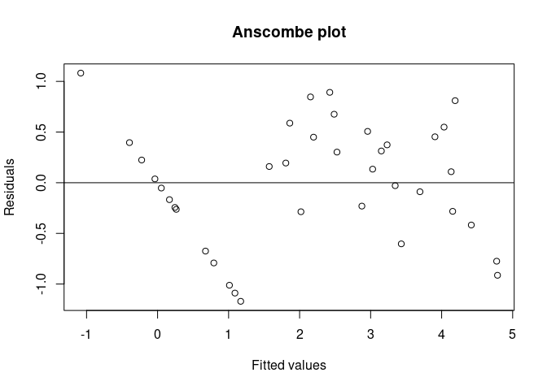

```r
plot(puff.sqlm$fit, puff.sqlm$res,xlab="Fitted values",ylab="Residuals", main="Anscombe plot")
abline(h=0)
```

```r
summary(puff.sqlm)
##
## Call:
## lm(formula = sqrtfreq ~ Grass_Cover + Mean_Soil_Depth + Slope_Angle +
##     Distance_from_Edge, data = puffin)
##
## Residuals:
##      Min       1Q   Median       3Q      Max
## -1.17058 -0.28555  0.07289  0.43606  1.08192
##
## Coefficients:
##                      Estimate Std. Error t value Pr(>|t|)
## (Intercept)         4.4176153  0.7479664   5.906 1.27e-06 ***
## Grass_Cover         0.0004179  0.0045698   0.091   0.9277
## Mean_Soil_Depth     0.0486374  0.0181385   2.681   0.0114 *
## Slope_Angle        -0.0318777  0.0182695  -1.745   0.0903 .
## Distance_from_Edge -0.1189727  0.0134970  -8.815 3.45e-10 ***
## ---
## Signif. codes:  0 '***' 0.001 '**' 0.01 '*' 0.05 '.' 0.1 ' ' 1
##
## Residual standard error: 0.6217 on 33 degrees of freedom
## Multiple R-squared:  0.8853, Adjusted R-squared:  0.8714
## F-statistic: 63.67 on 4 and 33 DF,  p-value: 4.753e-15

#####################################
# F test for two betas at the  same time:
######################################

puff.sqlm2 <- lm(sqrtfreq~ Mean_Soil_Depth + Distance_from_Edge, data=puffin)

anova(puff.sqlm)
## Analysis of Variance Table
##
## Response: sqrtfreq
##                    Df Sum Sq Mean Sq F value    Pr(>F)
## Grass_Cover         1  7.307   7.307  18.904 0.0001241 ***
## Mean_Soil_Depth     1  0.820   0.820   2.122 0.1546449
## Slope_Angle         1 60.278  60.278 155.945 4.725e-14 ***
## Distance_from_Edge  1 30.034  30.034  77.700 3.453e-10 ***
## Residuals          33 12.756   0.387
## ---
## Signif. codes:  0 '***' 0.001 '**' 0.01 '*' 0.05 '.' 0.1 ' ' 1
anova(puff.sqlm2)
## Analysis of Variance Table
##
## Response: sqrtfreq
##                    Df Sum Sq Mean Sq  F value Pr(>F)
## Mean_Soil_Depth     1  0.513   0.513   1.2596 0.2694
## Distance_from_Edge  1 96.437  96.437 236.9547 <2e-16 ***
## Residuals          35 14.245   0.407
## ---
## Signif. codes:  0 '***' 0.001 '**' 0.01 '*' 0.05 '.' 0.1 ' ' 1

fval <-  1/2*(14.245-12.756)/0.387

# 1.924
 qf(0.95, 2, 33)
## [1] 3.284918
# 3.28
 1-pf(fval, 2, 33)
## [1] 0.1620835
# 0.162

anova(puff.sqlm2, puff.sqlm)
## Analysis of Variance Table
##
## Model 1: sqrtfreq ~ Mean_Soil_Depth + Distance_from_Edge
## Model 2: sqrtfreq ~ Grass_Cover + Mean_Soil_Depth + Slope_Angle + Distance_from_Edge
##   Res.Df    RSS Df Sum of Sq     F Pr(>F)
## 1     35 14.245
## 2     33 12.756  2    1.4889 1.926 0.1618
```

```r
summary(emissions)
```

```
 Make              Odometer         Capacity         CS505
```

Length:54 Min. : 7285 Min. :1.300 Min. : 3.675  
Class :character 1st Qu.: 44208 1st Qu.:1.600 1st Qu.: 8.364  
Mode :character Median : 80164 Median :2.000 Median :10.598  
Mean : 84444 Mean :2.346 Mean :10.949  
3rd Qu.:117248 3rd Qu.:2.900 3rd Qu.:13.125  
Max. :232574 Max. :5.000 Max. :21.475  
T867 H505 ADR27 ADR37  
Min. : 1.158 Min. : 1.340 Min. :0.480 Min. :0.340  
1st Qu.: 4.188 1st Qu.: 4.884 1st Qu.:1.053 1st Qu.:1.005  
Median : 6.769 Median : 8.795 Median :1.475 Median :1.423  
Mean : 7.217 Mean : 9.376 Mean :1.525 Mean :1.478  
3rd Qu.:10.001 3rd Qu.:12.906 3rd Qu.:1.981 3rd Qu.:2.029  
Max. :15.982 Max. :21.465 Max. :2.851 Max. :2.862  
logCS505 logT867 logH505 logADR27  
Min. :1.302 Min. :0.1466 Min. :0.2927 Min. :-0.73397  
1st Qu.:2.124 1st Qu.:1.4322 1st Qu.:1.5850 1st Qu.: 0.05191  
Median :2.361 Median :1.9104 Median :2.1742 Median : 0.38857  
Mean :2.318 Mean :1.8185 Mean :2.0440 Mean : 0.33895  
3rd Qu.:2.575 3rd Qu.:2.3026 3rd Qu.:2.5577 3rd Qu.: 0.68382  
Max. :3.067 Max. :2.7715 Max. :3.0664 Max. : 1.04765  
logADR37  
Min. :-1.078810  
1st Qu.: 0.004947  
Median : 0.352585  
Mean : 0.290615  
3rd Qu.: 0.707568  
Max. : 1.051611

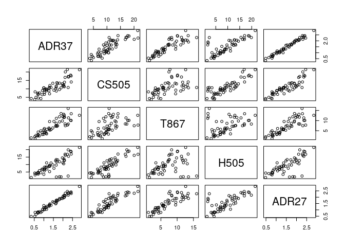

```r
 rawdata <- emissions[, c(8, 4:7)]
 pairs(rawdata)
```

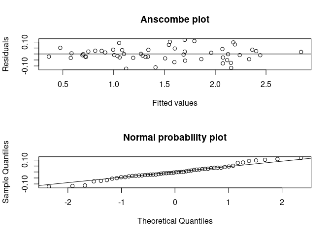

```r
# Fit the model on the raw scale
raw.lm <- lm(ADR37 ~ ADR27 + CS505  + T867 + H505, data=rawdata)
old.par <- par(no.readonly = TRUE)
par(mfrow=c(2,1))
plot(raw.lm$fit, raw.lm$res,xlab="Fitted values",ylab="Residuals", main="Anscombe plot")
abline(h=0)
qqnorm(raw.lm$res,main="Normal probability plot")
qqline(raw.lm$res)
```

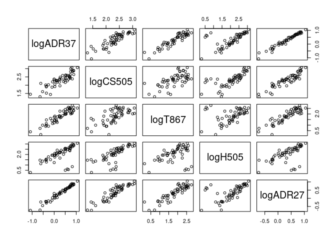

```r
# summary(raw.lm)
logdata <- log(rawdata)
# This only logs the values but not the column names!
# We can use the following command to change the column names or you can use
# fix(logdata) to do it.
dimnames(logdata)[[2]] <- c("logADR37", "logCS505", "logT867", "logH505", "logADR27")
pairs(logdata)
```

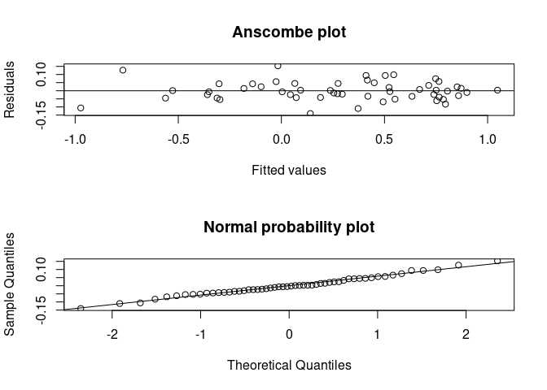

```r
log.lm <- lm(logADR37 ~ logADR27 + logCS505  + logT867 + logH505, data=logdata)
plot(log.lm$fit, log.lm$res,xlab="Fitted values",ylab="Residuals", main="Anscombe plot")
abline(h=0)
qqnorm(log.lm$res,main="Normal probability plot")
qqline(log.lm$res)
```

```r
summary(log.lm)
```

Call: lm(formula = logADR37 ~ logADR27 + logCS505 + logT867 + logH505, data = logdata)

Residuals: Min 1Q Median 3Q Max -0.140390 -0.038389 -0.003712 0.040204 0.153275

Coefficients: Estimate Std. Error t value Pr(>|t|)  
(Intercept) -0.12997 0.43073 -0.302 0.764119  
logADR27 0.94173 0.24140 3.901 0.000292 logCS505 -0.16790 0.16086 -1.044 0.301712  
logT867 0.15736 0.08986 1.751 0.086177 .  
logH505 0.09997 0.01857 5.385 2.04e-06 — Signif. codes: 0 ‘**’ 0.001 ’**’ 0.01 ’’ 0.05 ‘.’ 0.1 ’ ’ 1

Residual standard error: 0.06038 on 49 degrees of freedom Multiple R-squared: 0.9852, Adjusted R-squared: 0.984 F-statistic: 815.9 on 4 and 49 DF, p-value: < 2.2e-16

```r
log.lm2 <- lm(logADR37 ~ logADR27 + logT867 + logH505, data=logdata)
summary(log.lm2)
```

Call: lm(formula = logADR37 ~ logADR27 + logT867 + logH505, data = logdata)

Residuals: Min 1Q Median 3Q Max -0.157932 -0.039221 -0.004817 0.038672 0.157626

Coefficients: Estimate Std. Error t value Pr(>|t|)  
(Intercept) -0.57484 0.06231 -9.226 2.25e-12 *logADR27 0.69588 0.05289 13.157 < 2e-16* logT867 0.24471 0.03275 7.472 1.10e-09 *logH505 0.09030 0.01610 5.608 8.85e-07* — Signif. codes: 0 ‘**’ 0.001 ’**’ 0.01 ’’ 0.05 ‘.’ 0.1 ’ ’ 1

Residual standard error: 0.06043 on 50 degrees of freedom Multiple R-squared: 0.9849, Adjusted R-squared: 0.984 F-statistic: 1086 on 3 and 50 DF, p-value: < 2.2e-16

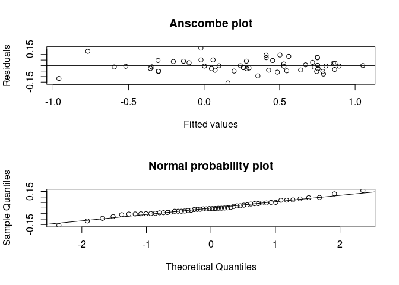

```r
plot(log.lm2$fit, log.lm2$res,xlab="Fitted values",ylab="Residuals", main="Anscombe plot")
abline(h=0)
qqnorm(log.lm2$res,main="Normal probability plot")
qqline(log.lm2$res)
```

```r
par(old.par)
#####################################
# Multicollinearity Analysis
######################################
mod.adr27 <-  lm(logADR27 ~ logT867 + logCS505 + logH505, data=logdata)
summary(mod.adr27) # Multiple R^2 = 0.9936,
```

Call: lm(formula = logADR27 ~ logT867 + logCS505 + logH505, data = logdata)

Residuals: Min 1Q Median 3Q Max -0.060363 -0.020065 -0.005929 0.015471 0.153280

Coefficients: Estimate Std. Error t value Pr(>|t|)  
(Intercept) -1.77188 0.02975 -59.56 < 2e-16 *logT867 0.36474 0.01052 34.66 < 2e-16* logCS505 0.65020 0.02063 31.52 < 2e-16 * **logH505 -0.02901 0.01007 -2.88 0.00584** — Signif. codes: 0 ‘**’ 0.001 ’**’ 0.01 ’’ 0.05 ‘.’ 0.1 ’ ’ 1

Residual standard error: 0.03537 on 50 degrees of freedom Multiple R-squared: 0.9936, Adjusted R-squared: 0.9932 F-statistic: 2589 on 3 and 50 DF, p-value: < 2.2e-16

```r
mod.t867 <-  lm(logT867 ~ logADR27 + logH505 + logCS505, data=logdata)
summary(mod.t867) # Multiple R^2 = 0.977,
```

Call: lm(formula = logT867 ~ logADR27 + logH505 + logCS505, data = logdata)

Residuals: Min 1Q Median 3Q Max -0.46512 -0.04505 0.01989 0.05619 0.16509

Coefficients: Estimate Std. Error t value Pr(>|t|)  
(Intercept) 4.64307 0.16840 27.572 <2e-16 *logADR27 2.63215 0.07594 34.663 <2e-16* logH505 0.07192 0.02739 2.626 0.0114 *  
logCS505 -1.66719 0.09218 -18.086 <2e-16 *** — Signif. codes: 0 ‘**’ 0.001 ’**’ 0.01 ’’ 0.05 ‘.’ 0.1 ’ ’ 1

Residual standard error: 0.09503 on 50 degrees of freedom Multiple R-squared: 0.977, Adjusted R-squared: 0.9757 F-statistic: 709.1 on 3 and 50 DF, p-value: < 2.2e-16

```r
mod.cs505 <-  lm(logCS505 ~ logADR27 + logH505 + logT867, data=logdata)
summary(mod.cs505) # Multiple R^2 = 0.9837,
```

Call: lm(formula = logCS505 ~ logADR27 + logH505 + logT867, data = logdata)

Residuals: Min 1Q Median 3Q Max -0.197444 -0.025126 0.008913 0.028843 0.104478

Coefficients: Estimate Std. Error t value Pr(>|t|)  
(Intercept) 2.64960 0.05473 48.411 < 2e-16 *logADR27 1.46430 0.04646 31.519 < 2e-16* logH505 0.05760 0.01415 4.072 0.000166 *logT867 -0.52029 0.02877 -18.086 < 2e-16* — Signif. codes: 0 ‘**’ 0.001 ’**’ 0.01 ’’ 0.05 ‘.’ 0.1 ’ ’ 1

Residual standard error: 0.05309 on 50 degrees of freedom Multiple R-squared: 0.9837, Adjusted R-squared: 0.9828 F-statistic: 1008 on 3 and 50 DF, p-value: < 2.2e-16

```r
mod.h505 <-  lm(logH505 ~ logADR27 + logCS505 + logT867, data=logdata)
summary(mod.h505) # Multiple R^2 = 0.5784,
```

Call: lm(formula = logH505 ~ logADR27 + logCS505 + logT867, data = logdata)

Residuals: Min 1Q Median 3Q Max -1.50570 -0.11784 0.07984 0.24783 0.85079

Coefficients: Estimate Std. Error t value Pr(>|t|)  
(Intercept) -9.3778 3.0009 -3.125 0.002959 ** logADR27 -4.9041 1.7029 -2.880 0.005844 ** logCS505 4.3236 1.0618 4.072 0.000166 ** *logT867 1.6848 0.6417 2.626 0.011444*  
— Signif. codes: 0 ‘**’ 0.001 ’**’ 0.01 ’’ 0.05 ‘.’ 0.1 ’ ’ 1

Residual standard error: 0.4599 on 50 degrees of freedom Multiple R-squared: 0.5784, Adjusted R-squared: 0.5531 F-statistic: 22.87 on 3 and 50 DF, p-value: 1.849e-09

```r
# Variance inflation factors
vifs <- c(0.9936, 0.977, 0.9837, 0.5784)
vifs <- 1/(1-vifs)
#Condition numbers
X <- logdata
# X is a copy of logdata
X[,1] <- 1
# the first column of X is 1
# this is for the intercept
X <- as.matrix(X)
# Coerces X to be a matrix
xtx <- t(X) %*% X # Gives X^T X
eigenvalues <- eigen(xtx)$values
kappa <- max(eigenvalues)/min(eigenvalues)
kappa <- sqrt(kappa)
# kappa = 244 is much LARGER than 30!

### Validation statistic
# Fit the log.lm2 model with the first 45 observations
# use the fitted model to predict the remaining 9 observations
# Calculate the mean square error validation statistic
log.lmsub <- lm(logADR37 ~ logADR27 + logT867 + logH505, data=logdata, subset=1:45)
# Now predict all 54 observations using the fitted model
mod.pred <- predict(log.lmsub, logdata, se.fit=TRUE)
mod.pred$fit # provides all the 54 predicted values
```

```
       1            2            3            4            5            6
```

0.869733716 0.751945766 0.464377364 0.065106368 -0.750908661 0.676749888 7 8 9 10 11 12 0.863161161 0.533123773 0.724024242 0.101489732 0.758165626 -0.009235144 13 14 15 16 17 18 0.262467812 0.499359749 0.896844370 -0.512513262 0.860758626 0.288778088 19 20 21 22 23 24 0.638085289 0.691680440 0.047967101 -0.125585969 0.542661299 -0.298423547 25 26 27 28 29 30 -0.607263492 0.529236907 0.296110240 0.476668407 -0.343488224 0.286358929 31 32 33 34 35 36 0.732443474 0.740078857 -0.002182982 0.421013296 -0.201423341 0.002081194 37 38 39 40 41 42 0.782644479 -0.305494632 -0.978948479 0.130633957 0.245486987 0.071403922 43 44 45 46 47 48 0.781436122 0.341921707 0.195907253 0.425131377 -0.094842350 0.754611045 49 50 51 52 53 54 0.444664924 0.353051544 0.805738645 -0.303182437 -0.356706826 1.052803842

```r
logdata$pred <- mod.pred$fit
# Get only last 9
a <- logdata[46:54, ]
validation.residuals <- a$logADR37 - a$pred
validation.stat <- mean(validation.residuals^2)
validation.stat
```

[1] 0.005814136